# Title: Identification of Gene sets

## Reference:

[PangloaDB](https://panglaodb.se/) [AUCell: Identifying cells with active gene sets](https://bioconductor.org/packages/release/bioc/vignettes/AUCell/inst/doc/AUCell.html) [Tabular Muris lung h5ad data](https://figshare.com/articles/dataset/Tabula_Muris_Senis_Data_Objects/12654728?file=23873012)

## Goal

Which of your cells are actively expressing a gene set? AUCell allows to label cells in a Seraut object which are enriched for user provided genes. This method is useful if you want to find which cells express a certain set of genes. These can be putative identity markers, response genes of some biological pathway, or any set of genes you are interested in. AUCell is a widely used and cited package.

PangloaDB, is an extremely useful database for cell identity markers in human and mouse single-cell data.

## Load packages

```r
if (!require("pacman", quietly = TRUE))
  install.packages("pacman")
remotes::install_github("mojaveazure/seurat-disk", force = TRUE)
```

[output not shown]

```
##
##  C:\Users\user\AppData\Local\Temp\RtmpSoeb52\downloaded_packages
```

```
## installing the source packages 'Rcpp', 'fansi', 'spatstat.geom'
```

```r
p_load(pacman, tidyverse, Seurat, AUCell, SeuratDisk)
```

## Load data

```r
load("../../data/droplet_Lung_seurat_tiss.Robj")
tiss <- UpdateSeuratObject(object = tiss)
```

```
## Updating from v2.X to v3.X
```

```
## Validating object structure
```

```
## Updating object slots
```

```
## Ensuring keys are in the proper structure
```

```
## Ensuring feature names don't have underscores or pipes
```

```
## Object representation is consistent with the most current Seurat version
```

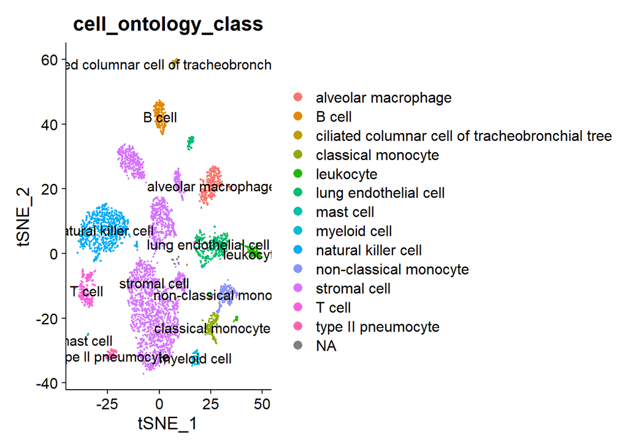

```r
DimPlot(tiss, label = TRUE, group.by = "cell_ontology_class")
```

## Select markers for endothelial cells

Endothelial cells would be identified, then gene symbols would be converted to follow conventions

```r
markers <- read.csv("../../data/PanglaoDB_markers_27_Mar_2020.tsv", sep = "\t")
markers <- markers[markers$cell.type == "Endothelial cells" & markers$species != "Hs",]
markers$official.gene.symbol <- str_to_title(markers$official.gene.symbol)
```

## Identification of Enriched Genes

```r
counts <- GetAssayData(tiss, slot = "counts")
cell_rankings <- AUCell_buildRankings(counts)
```

```
## Quantiles for the number of genes detected by cell:
## (Non-detected genes are shuffled at the end of the ranking. Keep it in mind when choosing the threshold for calculating the AUC).
```

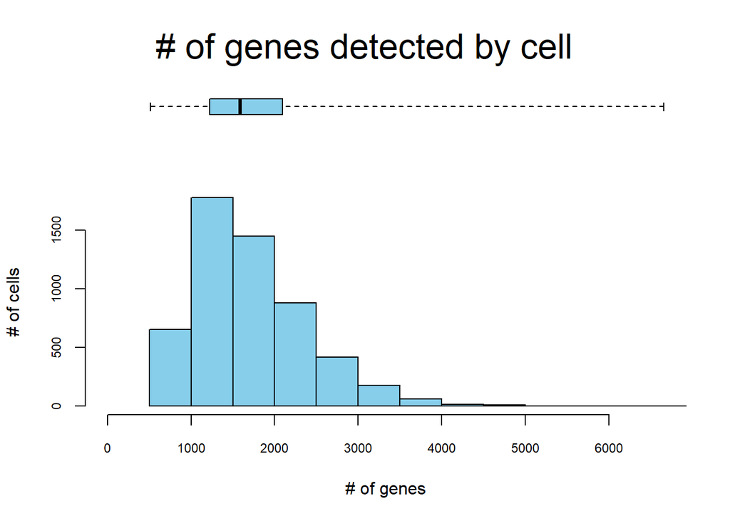

```
##     min      1%      5%     10%     50%    100%
##  516.00  612.48  792.40  947.60 1587.00 6658.00
```

```r
genes <- markers$official.gene.symbol
cell_auc <- AUCell_calcAUC(genes, cell_rankings)
```

```
## Genes in the gene sets NOT available in the dataset:
##  geneSet:    7 (4% of 189)
```

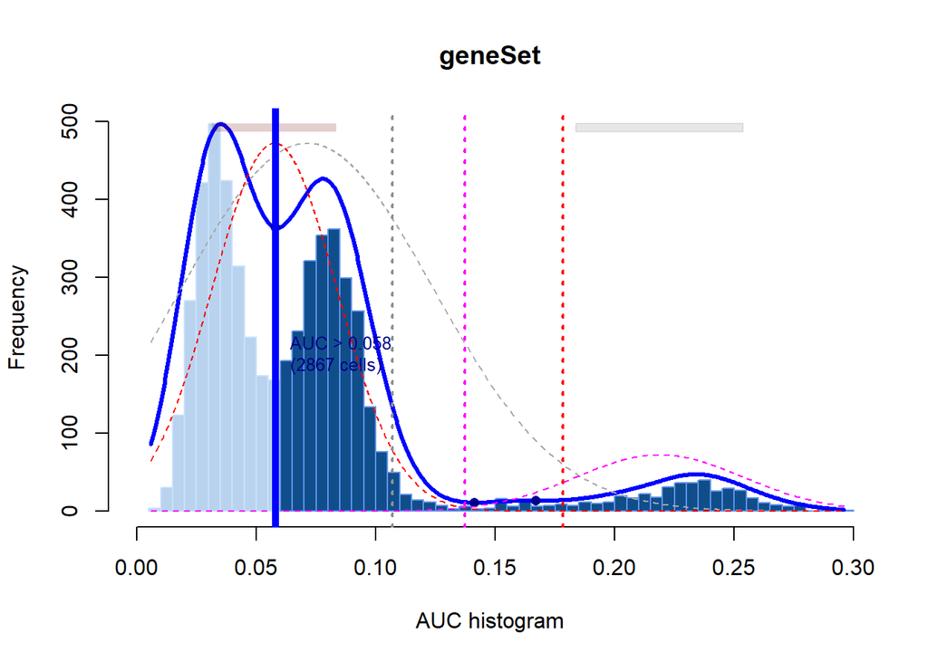

```r
cell_assignments <- AUCell_exploreThresholds(cell_auc, plotHist = TRUE, assign = TRUE)
```

We would adjust our threshold here to 0.15, because the out sample size is reflective of Lung Endothelial cells, hence giving us a much more representative population cell.

NB: AUCell does not work on every dataset, and ideally you want a bimodal distribution with one population not being too representative.

```r
new_cells <- names(which(getAUC(cell_auc)["geneSet", ] > 0.15))
tiss$is_ec <- ifelse(colnames(tiss) %in% new_cells, "EC", "non_EC")
```

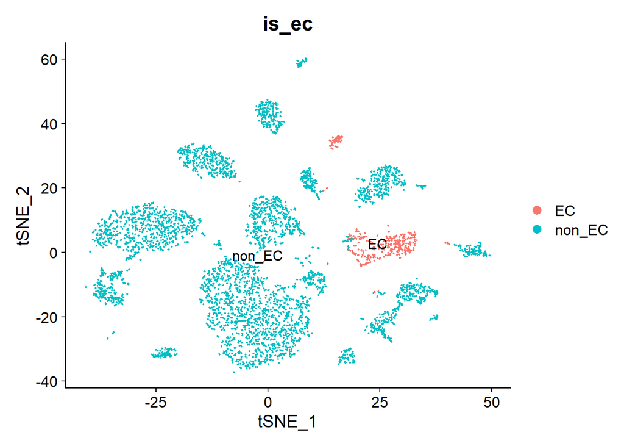

```r
DimPlot(tiss, group.by = "is_ec", label = TRUE)
```

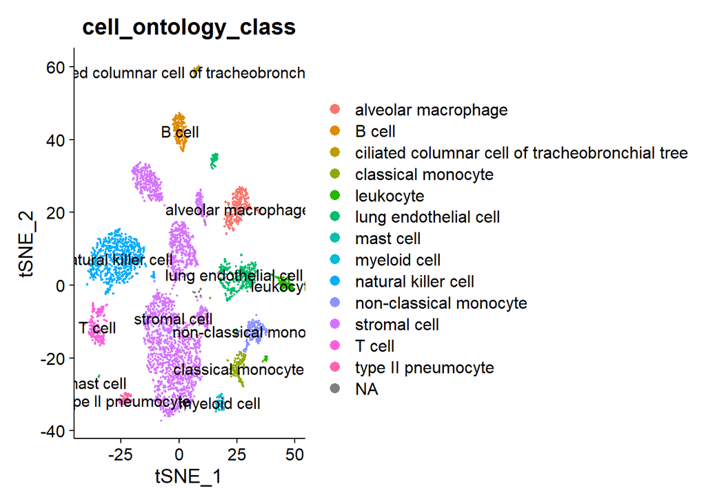

```r
DimPlot(tiss, label = TRUE, group.by = "cell_ontology_class")
```

## Unload packages and clear environment

```r
p_unload(pacman, tidyverse, Seurat, AUCell, SeuratDisk)
```

```
## The following packages have been unloaded:
## pacman, tidyverse, Seurat, AUCell, SeuratDisk
```

```r
rm(list = ls())
```